# [eb1] Analyses

Egor Ananyev

2019-01-04

# Data and function input

```r
# options(width=100)
library(plyr)
library(dplyr)
library(ggplot2)
library(lme4)
computer = 'acer'  # 'shocky', 'station3', 'acer' are all possible options
if(computer == 'shocky' || computer == 'toshi'){ dropbox_dir='/Users/Egor/Dropbox/' }
if(computer == 'acer'){ dropbox_dir='/Users/egora/Dropbox/' }
source(paste(dropbox_dir, 'Projects/eb/eb/an/funs_an/BF_t.R', sep='/'))
source(paste(dropbox_dir, 'Projects/eb/eb/an/funs_an/BF_U.R', sep='/'))
## Data input
ds1 = read.csv(paste(dropbox_dir, 'Projects/eb/eb/an/consolidated/ds1.csv', sep='/'))
dsa1 = read.csv(paste(dropbox_dir, 'Projects/eb/eb/an/consolidated/dsa1.csv', sep='/'))
ds2 = read.csv(paste(dropbox_dir, 'Projects/eb/eb/an/consolidated/ds2.csv', sep='/'))
dsa2 = read.csv(paste(dropbox_dir, 'Projects/eb/eb/an/consolidated/dsa2.csv', sep='/'))
```

# Linear models

```r
## Only including the predictive cueing condition from Expt 1:
ds1 = ds1[ds1$cue_pred==1,]
## Only including the trials within a certain CTOA range from Expt 2:
ds2 = ds2[ds2$ctoa <= max(ds1$ctoa),]
## Combining the two datasets:
ds = rbind(ds1, ds2)
## A better-named experiment column:
ds$expt = 'Expt1'
ds$expt[ds$exp_name=='eb2'] = 'Expt2'
## Sanity check
## Reordering the levels
ds$Cond <- factor(ds$Cond, c('Prompted','NoBlink','Artificial')) #this works for lm
```

## Sanity check model

A model confirming the effects of Expt 1.

```r
ds1$Cond <- factor(ds1$Cond, c('Prompted','NoBlink','Artificial')) #this works for lm
summary(lmer(RT~Cond*cue_valid + (1|subj), data=ds1))
```

```
## Linear mixed model fit by REML ['lmerMod']
## Formula: RT ~ Cond * cue_valid + (1 | subj)
##    Data: ds1
##
## REML criterion at convergence: 83503.4
##
## Scaled residuals:
##     Min      1Q  Median      3Q     Max
## -2.0964 -0.5663 -0.1577  0.3448  9.1171
##
## Random effects:
##  Groups   Name        Variance Std.Dev.
##  subj     (Intercept)  748.1   27.35
##  Residual             4503.1   67.10
## Number of obs: 7417, groups:  subj, 22
##
## Fixed effects:
##                          Estimate Std. Error t value
## (Intercept)              343.1841     6.4394  53.295
## CondNoBlink               -0.3955     3.8194  -0.104
## CondArtificial            -1.0533     3.8624  -0.273
## cue_valid                 -8.8057     3.1558  -2.790
## CondNoBlink:cue_valid     11.5093     4.4056   2.612
## CondArtificial:cue_valid   7.5990     4.4570   1.705
##
## Correlation of Fixed Effects:
##             (Intr) CndNBl CndArt cu_vld CnNB:_
## CondNoBlink -0.303
## CondArtifcl -0.300  0.506
## cue_valid   -0.367  0.619  0.612
## CndNBlnk:c_  0.263 -0.867 -0.438 -0.716
## CndArtfcl:_  0.260 -0.438 -0.866 -0.708  0.507
```

## Model with CTOA

```r
summary(lmer(RT~expt*Cond*cue_valid*ctoa + (1|subj), data=ds))
```

```
## Linear mixed model fit by REML ['lmerMod']
## Formula: RT ~ expt * Cond * cue_valid * ctoa + (1 | subj)
##    Data: ds
##
## REML criterion at convergence: 127783.6
##
## Scaled residuals:
##     Min      1Q  Median      3Q     Max
## -2.3105 -0.5874 -0.1522  0.3452  7.7272
##
## Random effects:
##  Groups   Name        Variance Std.Dev.
##  subj     (Intercept)  754     27.46
##  Residual             6196     78.72
## Number of obs: 11038, groups:  subj, 25
##
## Fixed effects:
##                                           Estimate Std. Error t value
## (Intercept)                             392.769731  32.779483  11.982
## exptExpt2                               192.210090  58.463241   3.288
## CondNoBlink                             -34.780233  45.569168  -0.763
## CondArtificial                           11.720580  45.495755   0.258
## cue_valid                                61.475286  37.446692   1.642
## ctoa                                     -0.061085   0.042150  -1.449
## exptExpt2:CondNoBlink                   -73.714784  85.218276  -0.865
## exptExpt2:CondArtificial                  6.232380  85.570784   0.073
## exptExpt2:cue_valid                     -61.274185  68.101964  -0.900
## CondNoBlink:cue_valid                    19.466909  52.659707   0.370
## CondArtificial:cue_valid                -48.525797  52.797236  -0.919
## exptExpt2:ctoa                           -0.144874   0.073955  -1.959
## CondNoBlink:ctoa                          0.046010   0.059043   0.779
## CondArtificial:ctoa                      -0.015970   0.059103  -0.270
## cue_valid:ctoa                           -0.090240   0.048750  -1.851
## exptExpt2:CondNoBlink:cue_valid         151.554138  98.442344   1.540
## exptExpt2:CondArtificial:cue_valid       34.128223  98.940952   0.345
## exptExpt2:CondNoBlink:ctoa                0.082573   0.107227   0.770
## exptExpt2:CondArtificial:ctoa            -0.005378   0.107757  -0.050
## exptExpt2:cue_valid:ctoa                  0.100914   0.086074   1.172
## CondNoBlink:cue_valid:ctoa               -0.011347   0.068208  -0.166
## CondArtificial:cue_valid:ctoa             0.072872   0.068499   1.064
## exptExpt2:CondNoBlink:cue_valid:ctoa     -0.191814   0.123912  -1.548
## exptExpt2:CondArtificial:cue_valid:ctoa  -0.047007   0.124594  -0.377
```

```
##
## Correlation matrix not shown by default, as p = 24 > 12.
## Use print(x, correlation=TRUE)  or
##     vcov(x)        if you need it
```

The model yields only one effect of significance: there is a significant increase in RT in Expt 2. Since there is no interaction with this effect, this applies across eye blink conditions and cue validities.

The fact that there is no effect of CTOA is good, because we can simply ignore it from now on… Although there *is* a marginally significant interaction of Expt# & CTOA, where CTOA in the second experiment is slightly more negative – implying slightly faster RTs in later time periods.

## Model without CTOA

```r
summary(lmer(RT~expt*Cond*cue_valid + (1|subj), data=ds))
```

```
## Linear mixed model fit by REML ['lmerMod']
## Formula: RT ~ expt * Cond * cue_valid + (1 | subj)
##    Data: ds
##
## REML criterion at convergence: 127942.3
##
## Scaled residuals:
##     Min      1Q  Median      3Q     Max
## -2.2440 -0.5893 -0.1625  0.3448  7.7898
##
## Random effects:
##  Groups   Name        Variance Std.Dev.
##  subj     (Intercept)  754.7   27.47
##  Residual             6311.2   79.44
## Number of obs: 11038, groups:  subj, 25
##
## Fixed effects:
##                                    Estimate Std. Error t value
## (Intercept)                        346.1905     6.3934  54.148
## exptExpt2                           74.3470     5.6313  13.203
## CondNoBlink                          0.1723     4.5213   0.038
## CondArtificial                      -0.9546     4.5722  -0.209
## cue_valid                           -8.2711     3.7359  -2.214
## exptExpt2:CondNoBlink               -6.4031     7.8842  -0.812
## exptExpt2:CondArtificial             0.7300     7.9630   0.092
## exptExpt2:cue_valid                 16.9883     6.4827   2.621
## CondNoBlink:cue_valid               11.1265     5.2156   2.133
## CondArtificial:cue_valid             7.6915     5.2762   1.458
## exptExpt2:CondNoBlink:cue_valid     -2.3192     9.0952  -0.255
## exptExpt2:CondArtificial:cue_valid  -0.7745     9.1890  -0.084
##
## Correlation of Fixed Effects:
##             (Intr) exptE2 CndNBl CndArt cu_vld exE2:CNB exE2:CA exE2:_
## exptExpt2   -0.297
## CondNoBlink -0.362  0.410
## CondArtifcl -0.358  0.406  0.506
## cue_valid   -0.438  0.497  0.619  0.612
## exptEx2:CNB  0.208 -0.709 -0.573 -0.290 -0.355
## exptExp2:CA  0.207 -0.703 -0.290 -0.574 -0.351  0.501
## exptExpt2:_  0.251 -0.860 -0.356 -0.353 -0.576  0.615    0.609
## CndNBlnk:c_  0.313 -0.356 -0.867 -0.438 -0.716  0.497    0.252   0.413
## CndArtfcl:_  0.310 -0.352 -0.438 -0.866 -0.708  0.251    0.497   0.408
## expE2:CNB:_ -0.179  0.613  0.497  0.251  0.411 -0.866   -0.434  -0.713
## exptE2:CA:_ -0.178  0.607  0.252  0.497  0.407 -0.434   -0.866  -0.705
##             CnNB:_ CndA:_ eE2:CNB:
## exptExpt2
## CondNoBlink
## CondArtifcl
## cue_valid
## exptEx2:CNB
## exptExp2:CA
## exptExpt2:_
## CndNBlnk:c_
## CndArtfcl:_  0.507
## expE2:CNB:_ -0.573 -0.291
## exptE2:CA:_ -0.291 -0.574  0.503
```

This model gives the same effect as the previous model, but also: 1) RT was faster on valid trials in Expt 1 than invalid trials in PB condition, confirming the results of Expt 1 (see the sanity check model above), 2) but this effect vanished in the No Blink condition 3) and *reversed* in Expt 2: the slope is now positive (~17 ms), implying IOR across blink conditions.

# Visualization

## Comparing Both Experiments

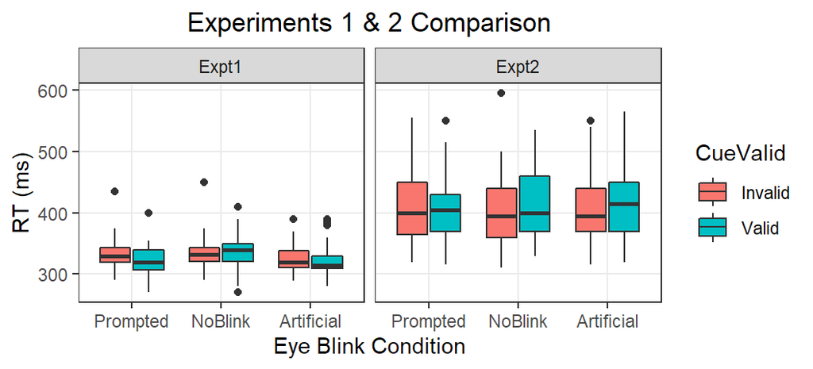

```r
sumss = ddply(ds, .(subj, expt, Cond, CueValid), summarise, RT=median(RT))
p = ggplot(data=sumss, aes(x=Cond, y=RT, fill=CueValid)) +
    geom_boxplot() + facet_grid(.~expt) + xlab('Eye Blink Condition') +
    ylab('RT (ms)') + theme_bw() +
    # geom_dotplot(binaxis='y', stackdir='center', dotsize=2, binwidth=3, ) +
    theme(panel.grid.minor=element_blank(),
          plot.title = element_text(hjust = 0.5)) + ggtitle('Experiments 1 & 2 Comparison')
plot(p)
```

```r
pdf('eb_box_expts1-2.pdf', width=5.5, height=2.5)
plot(p)
dev.off()
```